# Visual Data Understanding

- **Author: Prof. Nagiza F. Samatova**
- **Email: samatova@csc.ncsu.edu**
- **Date: September 27, 2018**

## Installing Relevant Packages

Here are some package relevant to this module that you may need to install from the terminal window (e.g., Anaconda's terminal) if you do not have them:

> ```
> pip install weightedstats
> pip install seaborn
> pip install plotly
> pip install ggplot
> # pip install biokit
> ```

# 1 Loading Relevant Packages

Load the relevant packages:

```python
import pandas as pd
import numpy as np
from scipy import stats

import matplotlib.pyplot as plt
%matplotlib inline

import seaborn as sns
from pandas.plotting import parallel_coordinates
from pandas.plotting import scatter_matrix
from scipy.cluster import hierarchy
import weightedstats as ws
from scipy.stats import wilcoxon

#from biokit.viz import corrplot
#import plotly.plotly as py
#import plotly.figure_factory as ff
#
```

# 2 Get Familiar with the Data

```python
state = pd.read_csv("../data_raw/eda_state.csv")
state.head()
```

|  | State | Population | Murder.Rate | Abbreviation |
| --- | --- | --- | --- | --- |
| 0 | Alabama | 4779736 | 5.7 | AL |
| 1 | Alaska | 710231 | 5.6 | AK |
| 2 | Arizona | 6392017 | 4.7 | AZ |
| 3 | Arkansas | 2915918 | 5.6 | AR |
| 4 | California | 37253956 | 4.4 | CA |

# 3 Univariate Analysis

## 3.1 Central Tendency: Quantitative Variable

- `np.mean(x)`: The *arithmetic mean*: The sum divided by the length
- `stats.trim_mean(x, proportioncut = 0.1)`: The *trimmed arithmetic mean*: the average of all values after dropping a fixed percentage of extreme values (e.g., `trim=0.1` for 10%)
- `np.median(x)`: The *median*: A value where 50% of x is above it, and 50% is below it
- `np.average(x, weights)`: The *weighted mean*: the sum of all values times a weight divided by the sum of all the weights
- `ws.weighted_median (data, weights)`: The *weighted median*: The value such that the sum of the weights is equal for the lower and upper halves of the sorted list of data values

### 3.1.1 Example: Location Estimates of Population and Murder Rates

Lets compute the mean, trimmed mean, and the median for the population:

```python
state.columns
```

```
Index(['State', 'Population', 'Murder.Rate', 'Abbreviation'], dtype='object')
```

```python
state.Population.mean()
```

```
6162876.3
```

```python
stats.trim_mean(state.Population,
                proportiontocut = 0.1)
```

```
4783697.125
```

```python
state.Population.median()
```

```
4436369.5
```

Note that that **the mean is bigger than the trimmed mean, which is bigger than the median**. This is because the trimmed mean excludes the largest and smallest five states (trim=0.1 drops 10 percent from each end).

To compute the average murder rate, we need to use the *weighted mean* or *weighted median*:

```python
np.average(state['Murder.Rate'],
           weights=state.Population)
```

```
4.445833981123393
```

```python
ws.weighted_median(state['Murder.Rate'],
                   weights=state.Population)
```

```
4.4
```

Note that the weighted mean and median are about the same.

- **Compare Medians**

```python
diet_1_change  = (+4, +3, 0, -3, -4, -5, -11, -14, -15, -300)
print ("{} : median : diet_1_change".format(np.median (diet_1_change)))
print ("{} : mean : diet_1_change".format(np.mean (diet_1_change) ) )
```

```
-4.5 : median : diet_1_change
-34.5 : mean : diet_1_change
```

```python
diet_2_change  = (-8, -10, -12, -16, -18, -20, -21, -24, -26, -30)
print ("{} : median : diet_2_change".format(np.median (diet_2_change)))
print ("{} : mean : diet_2_change".format(np.mean (diet_2_change) ) )
```

```
-19.0 : median : diet_2_change
-18.5 : mean : diet_2_change
```

```python
from scipy.stats import wilcoxon
wilcoxon(x = diet_1_change, y = diet_2_change)
```

```
WilcoxonResult(statistic=10.0, pvalue=0.07389705510759269)
```

```python
wilcoxon?
```

## 3.2 Central Tendency: Categorical Variable

For categorical data, simple proportions or percentages tell the story of the data. For example, to examine the percentage of delayed flights by the cause of delay, you can use the `barplot(x)` function. Delays are categorized as being due to factors under carrier control, air traffic control (ATC) system delays, weather, security, or late inbound aircrafts:

```python
dfw = pd.read_csv("../data_raw/eda_dfw_airline.csv")
dfw.columns
```

```
Index(['Carrier', 'ATC', 'Weather', 'Security', 'Inbound'], dtype='object')
```

```python
dfw.iloc[0]
```

```
Carrier      64263.16
ATC          84856.50
Weather      11235.42
Security       343.15
Inbound     118427.82
Name: 0, dtype: float64
```

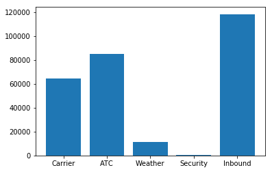

```python
plt.bar([1,2,3,4,5], dfw.iloc[0])
plt.xticks([1,2,3,4,5], dfw.columns)
plt.show()
```

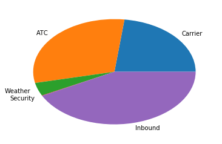

```python
plt.pie(dfw.iloc[0], labels = dfw.columns)
plt.show()
```

## 3.3 Measures of Variability: Quantitative Variable

- `np.var(x)`: *Variance*: the average distance from the mean
- `np.std(x)`: *Standard deviation*: sqrt(variance) or the average spread around the mean
- `stats.iqr(x)`: *Interquartile range*: the difference between the 75th percentile and the 25th percentile of the sorted data values
- `pd.mad()`: *Median absolute deivation*: the median of the absolute value of the deviations from the mean median(abs(x - mean(x)))
- `pd.quantile()`: Quantile of the data

```python
state = pd.read_csv("../data_raw/eda_state.csv")
np.std(state.Population)
```

```
6779407.114632265
```

```python
stats.iqr(state.Population)
```

```
4847308.0
```

```python
state.Population.mad()
```

```
4450933.356000001
```

```python
state['Murder.Rate'].quantile([0.05,0.25,0.5,0.75,0.95])
```

```
0.05    1.600
0.25    2.425
0.50    4.000
0.75    5.550
0.95    6.510
Name: Murder.Rate, dtype: float64
```

Note that standard deviation is almost 1.5 times as large as the MAD. This is not surprizing since the standard deviation is sensitive to outliers. There is quite a bit of variability: the 5th percentile is only 1.6 murders per 100,000 people and the 95th percentile is 6.51.

## 3.4 Exploring Data Distribution

A *boxplot* is based on percentiles and gives a quick way to visualize the distribution of data. In a boxplot, the top and bottom of the box are at the 75th and 25th percentiles, respectively.

[figure not shown]

```python
plt.boxplot(state.Population/100000)
plt.ylabel("Population (millions)")
plt.show()
```

A *histogram* is a way to visualize a frequency table, with bins on the $x$-axis and data count on the $y$-axis.

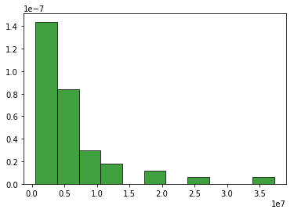

```python
plt.hist(state.Population, 11,
         normed=1,
         facecolor='green',
         alpha=0.75,
         edgecolor='black')
plt.show()
```

A *density plot* is a smoothed version of a histogram:

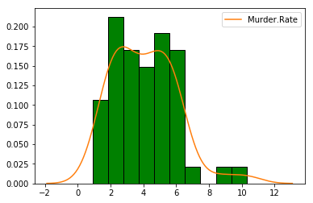

```python
plt.hist(state['Murder.Rate'],
         facecolor='green',
         density=True,
         edgecolor='black')

fig=sns.kdeplot(state['Murder.Rate'], legend=True)
plt.show()
```

# 4 Bivariate: Correlation and Scatterplot Matrices

## 4.1 Correlation Matrix

*Correlation* (`.corr(x, y)`) is a metric that measures the extent to which two numeric variables are associated with one another:

- Positive: if $x$) increases, then $y$ increases: +1 perfect positive correlation
- Negative: if $x$ increases, then $y$ decreases: -1 perfect negative correlation
- Zero: no association between them

Note the correlation between the daily returns for telecommunication stocks after July 2012: + Verizon (VZ) and ATT (T) have the highest correlation + Level Three (LVLT) infrastructure company has the lowest correlation

```python
sp500 = pd.read_csv("../data_raw/eda_sp500_data.csv")
sp500.shape
```

```
(5647, 518)
```

```python
sp500.head()
```

|  | Unnamed: 0 | ADS | CA | MSFT | RHT | CTSH | CSC | EMC | IBM | XRX | ... | WAT | ALXN | AMGN | BXLT | BIIB | CELG | GILD | REGN | VRTX | HSIC |
| --- | --- | --- | --- | --- | --- | --- | --- | --- | --- | --- | --- | --- | --- | --- | --- | --- | --- | --- | --- | --- | --- |
| 0 | 1993-01-29 | 0.0 | 0.060124 | -0.022100 | 0.0 | 0.0 | 0.018897 | 0.007368 | 0.092165 | 0.259140 | ... | 0.0 | 0.0 | 0.34716 | 0.0 | 0.04167 | 0.00000 | 0.015564 | 1.75 | 0.1250 | 0.0 |
| 1 | 1993-02-01 | 0.0 | -0.180389 | 0.027621 | 0.0 | 0.0 | 0.018889 | 0.018425 | 0.115207 | -0.100775 | ... | 0.0 | 0.0 | -0.23144 | 0.0 | 0.00000 | -0.01041 | 0.007782 | 1.25 | 0.1250 | 0.0 |
| 2 | 1993-02-02 | 0.0 | -0.120257 | 0.035900 | 0.0 | 0.0 | -0.075573 | 0.029482 | -0.023041 | 0.028796 | ... | 0.0 | 0.0 | -0.11572 | 0.0 | 0.00000 | 0.00000 | -0.007792 | -0.25 | 0.0000 | 0.0 |
| 3 | 1993-02-03 | 0.0 | 0.060124 | -0.024857 | 0.0 | 0.0 | -0.151128 | 0.003689 | -0.253454 | -0.043190 | ... | 0.0 | 0.0 | -0.08679 | 0.0 | 0.04167 | -0.04167 | -0.038919 | -0.50 | 0.0625 | 0.0 |
| 4 | 1993-02-04 | 0.0 | -0.360770 | -0.060757 | 0.0 | 0.0 | 0.113350 | -0.022114 | 0.069862 | 0.000000 | ... | 0.0 | 0.0 | 0.14465 | 0.0 | -0.04166 | -0.03126 | -0.046711 | 0.00 | 0.0625 | 0.0 |

5 rows × 518 columns

```python
sp500=sp500[sp500['Unnamed: 0']>'2012-07-01']
sp500.shape
```

```
(754, 518)
```

```python
symbols = ["T", "CTL", "FTR", "VZ", "LVLT"]
etfs=sp500[symbols]
etfs.shape
```

```
(754, 5)
```

```python
corr = etfs.corr(method='pearson')
corr
```

|  | T | CTL | FTR | VZ | LVLT |
| --- | --- | --- | --- | --- | --- |
| T | 1.000000 | 0.474683 | 0.327767 | 0.677612 | 0.278626 |
| CTL | 0.474683 | 1.000000 | 0.419757 | 0.416604 | 0.286665 |
| FTR | 0.327767 | 0.419757 | 1.000000 | 0.287386 | 0.260068 |
| VZ | 0.677612 | 0.416604 | 0.287386 | 1.000000 | 0.242199 |
| LVLT | 0.278626 | 0.286665 | 0.260068 | 0.242199 | 1.000000 |

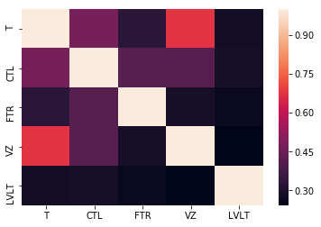

```python
# plot the heatmap
#plt.figure(figsize=(7,7))
sns.heatmap(corr,
        xticklabels=corr.columns,
        yticklabels=corr.columns)
plt.show()
```

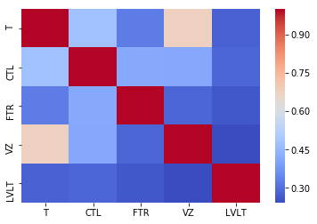

```python
# Change the color palette by using
# the cmap parameter: https://seaborn.pydata.org/tutorial/color_palettes.html
sns.heatmap(corr,
            cmap='coolwarm')
plt.show()
```

```python
pd.DataFrame.corr?
```

If you wanted to be even more fancy, you can use Pandas Style (http://pandas.pydata.org/pandas-docs/stable/style.html), for example:

```python
cmap = cmap=sns.diverging_palette(5, 250, as_cmap=True)

def magnify():
    return [dict(selector="th",
                 props=[("font-size", "7pt")]),
            dict(selector="td",
                 props=[('padding', "0em 0em")]),
            dict(selector="th:hover",
                 props=[("font-size", "12pt")]),
            dict(selector="tr:hover td:hover",
                 props=[('max-width', '200px'),
                        ('font-size', '12pt')])
]

corr.style.background_gradient(cmap, axis=1)\
    .set_properties(**{'max-width': '80px', 'font-size': '10pt'})\
    .set_caption("Telecommunication Stock Performance Correlation")\
    .set_precision(2)\
    .set_table_styles(magnify())
```

Telecommunication Stock Performance Correlation

|  | T | CTL | FTR | VZ | LVLT |
| --- | --- | --- | --- | --- | --- |
| T | 1 | 0.47 | 0.33 | 0.68 | 0.28 |
| CTL | 0.47 | 1 | 0.42 | 0.42 | 0.29 |
| FTR | 0.33 | 0.42 | 1 | 0.29 | 0.26 |
| VZ | 0.68 | 0.42 | 0.29 | 1 | 0.24 |
| LVLT | 0.28 | 0.29 | 0.26 | 0.24 | 1 |

## 4.2 Scatterplot Matrix for Predictor Variables

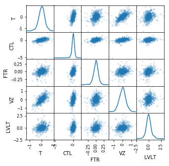

```python
from pandas.plotting import scatter_matrix
scatter_matrix(etfs, alpha=0.2,
               figsize=(5, 5),
               diagonal='kde')
plt.show()
```

```python
# https://seaborn.pydata.org/generated/seaborn.pairplot.html
```

```python
sns.pairplot?
```

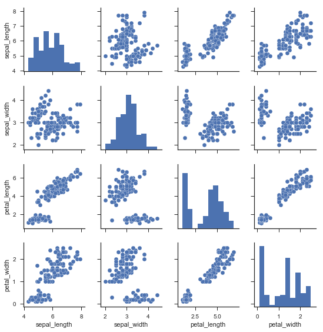

```python
# import seaborn as sns
sns.set(style="ticks", color_codes=True)

iris = sns.load_dataset("iris")
g = sns.pairplot(iris,
                 size=2.0)
```

```python
scatter_matrix?
```

## 4.3 Scatterplot Matrix for Predictor Variables and a Response Variable

For scatterplot matrices, it is often insightful to see the pair-wise relationships between numeric predictors within each group/class of the response variable (note `hue=` followed by the response variable `species`). This way a relationship between two predictor variables and one response variable is being captured:

```python
sns.pairplot?
```

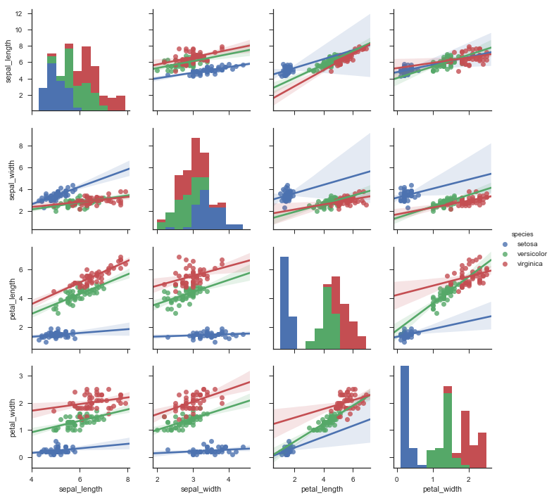

```python
import seaborn as sns
sns.set(style="ticks", color_codes=True)
iris = sns.load_dataset("iris")

sns.pairplot(iris,
             diag_kind='hist',
             hue="species",
             kind="reg")
plt.show()
```

## 4.4 Hexagonal Binning for Quantitative Variables

```python
# https://matplotlib.org/gallery/statistics/hexbin_demo.html
```

Scatterplots are fine for small sample sizes. Otherwise, they will be too dense to visualize the relationships. A *hexagon binning* plot addresses this issue, as illustrated on the `kc_tax` data that contains values for residential properties in King County, Washington:

```python
kc_tax=pd.read_csv("../data_raw/eda_kc_tax.csv")
kc_tax=kc_tax.query('TaxAssessedValue<750000 & SqFtTotLiving > 100 & SqFtTotLiving < 3500')
kc_tax.shape
```

[output not shown]

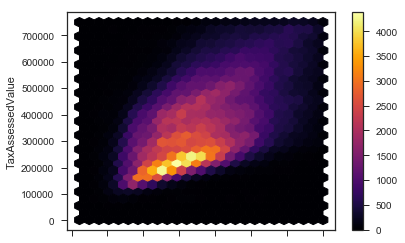

```python
kc_tax.plot.hexbin(x='SqFtTotLiving',
                   y='TaxAssessedValue',
                   gridsize = 25,
                   cmap='inferno')
plt.xlabel('Finished Square Feet')
plt.show()
```

## 4.5 Correlation Plots

```python
df = sns.load_dataset("iris")
df.head()
```

|  | sepal_length | sepal_width | petal_length | petal_width | species |
| --- | --- | --- | --- | --- | --- |
| 0 | 5.1 | 3.5 | 1.4 | 0.2 | setosa |
| 1 | 4.9 | 3.0 | 1.4 | 0.2 | setosa |
| 2 | 4.7 | 3.2 | 1.3 | 0.2 | setosa |
| 3 | 4.6 | 3.1 | 1.5 | 0.2 | setosa |
| 4 | 5.0 | 3.6 | 1.4 | 0.2 | setosa |

```python
df_corr_matrix = df.corr()
df_corr_matrix.head()
```

|  | sepal_length | sepal_width | petal_length | petal_width |
| --- | --- | --- | --- | --- |
| sepal_length | 1.000000 | -0.117570 | 0.871754 | 0.817941 |
| sepal_width | -0.117570 | 1.000000 | -0.428440 | -0.366126 |
| petal_length | 0.871754 | -0.428440 | 1.000000 | 0.962865 |
| petal_width | 0.817941 | -0.366126 | 0.962865 | 1.000000 |

```python
# from biokit.viz import corrplot
# c = corrplot.Corrplot(df_corr_matrix)
# c.plot()
```

### Correlation: Statistical Significance

```python
import seaborn as sns
df = sns.load_dataset("iris")

from scipy import stats

pearson_coef, p_value = stats.pearsonr(df["petal_length"],
                                       df["petal_width"])
print("Pearson Correlation Coefficient: ", pearson_coef,
      "\nand a P-value of:", p_value)
```

```
Pearson Correlation Coefficient:  0.9628654314027961
and a P-value of: 4.675003907327543e-86
```

# 5 Bivariate: Compare Quantitaive Variable against Categorical Variable

- A *Violin* plot: plots the density estimate with the density on the $y$-axis and the categorical variable on the $x$-axis
- Density is mirrored and flipped: hence, $violin$
- Pros: Unlike boxplots, they can show nuances in the distribution
- Cons: Boxplot more clearly shows outliers

```python
airlines= pd.read_csv("../data_raw/eda_airline_stats.csv")
airlines.head()
```

|  | pct_carrier_delay | pct_atc_delay | pct_weather_delay | airline |
| --- | --- | --- | --- | --- |
| 0 | 8.153226 | 1.971774 | 0.762097 | American |
| 1 | 5.959924 | 3.706107 | 1.585878 | American |
| 2 | 7.157270 | 2.706231 | 2.026706 | American |
| 3 | 12.100000 | 11.033333 | 0.000000 | American |
| 4 | 7.333333 | 3.365591 | 1.774194 | American |

```python
sns.violinplot?
```

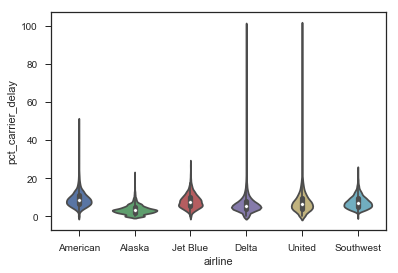

```python
# https://seaborn.pydata.org/generated/seaborn.violinplot.html
# http://seaborn.pydata.org/examples/grouped_violinplots.html
# https://python-graph-gallery.com/violin-plot/
sns.violinplot(x="airline",
               y="pct_carrier_delay",
               data=airlines)
plt.show()
```

## 5.2 Boxplot

```python
airlines= pd.read_csv("../data_raw/eda_airline_stats.csv")
airlines.head()
```

|  | pct_carrier_delay | pct_atc_delay | pct_weather_delay | airline |
| --- | --- | --- | --- | --- |
| 0 | 8.153226 | 1.971774 | 0.762097 | American |
| 1 | 5.959924 | 3.706107 | 1.585878 | American |
| 2 | 7.157270 | 2.706231 | 2.026706 | American |
| 3 | 12.100000 | 11.033333 | 0.000000 | American |
| 4 | 7.333333 | 3.365591 | 1.774194 | American |

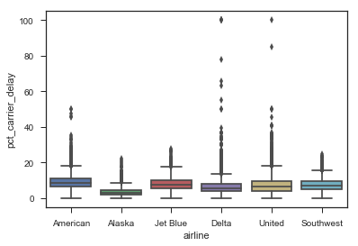

```python
sns.boxplot(x="airline", y="pct_carrier_delay", data=airlines)
plt.show()
```

# 6 Multivariate: Visual Exploration of Multiple Variables

## 6.1 Conditioning or Facets (sns.factorplot)

Some charts can be extended to more tnan 2 variables using `sns.factorplot()`. It must be noted that `sns.factorplot` only supports {point, bar, count, box, violin, strip} type of plots at the moment. Otherwise, grouping and subsetting can be used to generate plots extended to more than 2 variables.

```python
kc_tax=pd.read_csv("../data_raw/eda_kc_tax.csv")
kc_tax=kc_tax.query('TaxAssessedValue<750000 & SqFtTotLiving > 100 & SqFtTotLiving < 3500')
```

```python
kc_tax.shape
```

```
(432693, 3)
```

```python
#https://blog.insightdatascience.com/data-visualization-in-python-advanced-functionality-in-seaborn-20d217f1a9a6
```

```python
# sns.factorplot(x="SqFtTotLiving",
#                y="TaxAssessedValue",
#                row="ZipCode",
#                data=kc_tax,
#                kind='strip')
# plt.show()
```

## 6.2 Parallel Coordinates Plot

The *parallel coordinates* plot is useful for creating the profiles for different clusters or groups of the data, as they allow for visual summeries of how observations within the same groups are similar across multiple variables, as well as how they are different from other group observations:

```python
df = sns.load_dataset("iris")
df.head()
```

|  | sepal_length | sepal_width | petal_length | petal_width | species |
| --- | --- | --- | --- | --- | --- |
| 0 | 5.1 | 3.5 | 1.4 | 0.2 | setosa |
| 1 | 4.9 | 3.0 | 1.4 | 0.2 | setosa |
| 2 | 4.7 | 3.2 | 1.3 | 0.2 | setosa |
| 3 | 4.6 | 3.1 | 1.5 | 0.2 | setosa |
| 4 | 5.0 | 3.6 | 1.4 | 0.2 | setosa |

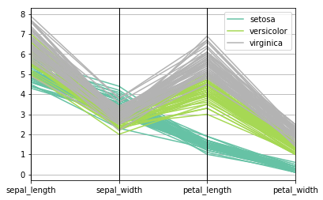

```python
# http://benalexkeen.com/parallel-coordinates-in-matplotlib/
# https://python-graph-gallery.com/150-parallel-plot-with-pandas/
from pandas.plotting import parallel_coordinates
parallel_coordinates(df, 'species',
                    colormap=plt.get_cmap("Set2"))
plt.show()
```

## 6.3 Cluster Dendrogram: Hierarchical Relationships

*Cluster Dendrogram* is a hierarchical tree-like relationship among multiple variables or observations: the closer to the bottom of the tree, the more similar or correlated they are:

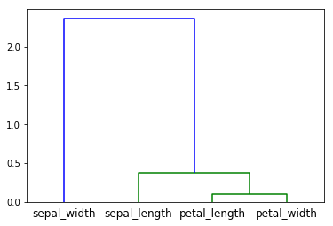

```python
#https://python-graph-gallery.com/dendrogram/
df = sns.load_dataset("iris")
data=df.corr()
Z = hierarchy.linkage(data, 'single')
plt.figure()
dn = hierarchy.dendrogram(Z,labels=data.columns)
```